# Data Analysis HW6

Artin Tajdini 95109983

April 12, 2018

# سؤال ۱

ماتریس کورلیشن را در می آوردیم سپس با زدن کورلیشن تست دو به دو صحت را بررسی میکنیم(نمودار پی ولیو ها را رسم میکنیم و پیولیو های پایین به معنی ارتباط داشتن دو متغیر است) با Hmisc::rcorr کورلیشن تست میزنیم

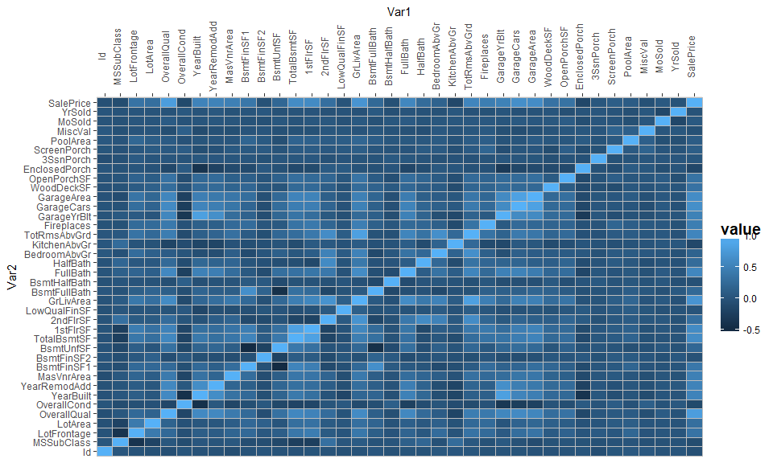

```r
cor( select_if(house, is.numeric), use = "complete.obs" ) %>%
  reshape2::melt() %>%
  ggplot(aes(Var1, Var2, fill = value)) +
  geom_tile(color = "gray") +
  theme(
    axis.text.x = element_text(angle = 90),
    panel.grid.major.x=element_blank(),
    panel.grid.minor.x=element_blank(),
    panel.grid.major.y=element_blank(),
    panel.grid.minor.y=element_blank()
  ) +
  theme(legend.title=element_text(face="bold", size=14)) +
  scale_y_discrete() +
  scale_x_discrete(expand = c(0, 0), position = "top")
```

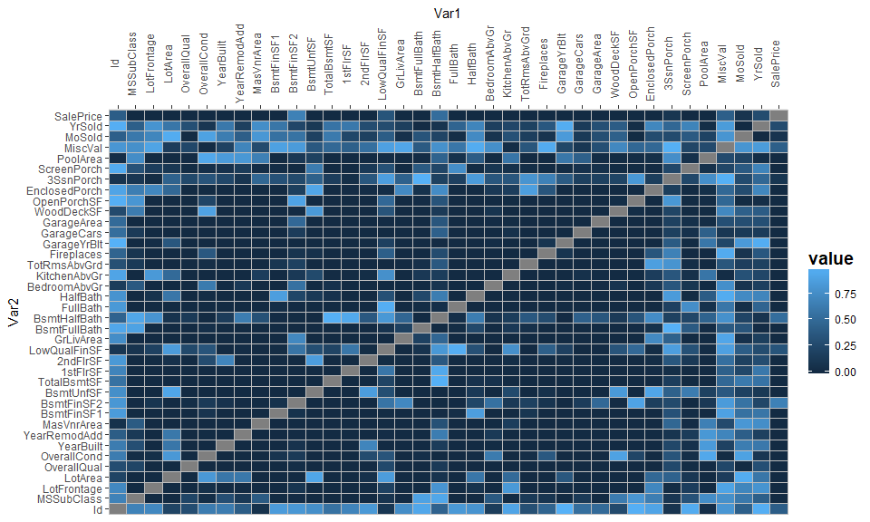

```r
tt = Hmisc::rcorr( as.matrix(select_if(house, is.numeric)) )
tt$P %>%
  reshape2::melt() %>%
  ggplot(aes(Var1, Var2, fill = value)) +
  geom_tile(color = "gray") +
  theme(
    axis.text.x = element_text(angle = 90),
    panel.grid.major.x=element_blank(),
    panel.grid.minor.x=element_blank(),
    panel.grid.major.y=element_blank(),
    panel.grid.minor.y=element_blank()
  ) +
  theme(legend.title=element_text(face="bold", size=14)) +
  scale_y_discrete() +
  scale_x_discrete(expand = c(0, 0), position = "top")
```

```r
  cor( select_if(house, is.numeric), use = "complete.obs" ) %>%
  reshape2::melt() %>% filter(Var1 == "SalePrice") %>%
  arrange( desc(abs(value)) ) %>%
  slice(1:11) %>% .$Var2 -> c1
  c1
```

```
 [1] SalePrice    OverallQual  GrLivArea    GarageCars   GarageArea
 [6] TotalBsmtSF  1stFlrSF     FullBath     TotRmsAbvGrd YearBuilt
[11] YearRemodAdd
38 Levels: Id MSSubClass LotFrontage LotArea OverallQual ... SalePrice
```

# سوال ۲

از این ۵۵ نمودار میابیم که بعضی از متغیر ها با اینکه همبستگی دارند اما ارتباطشان خطی نیست مانند قیمت و overalQual

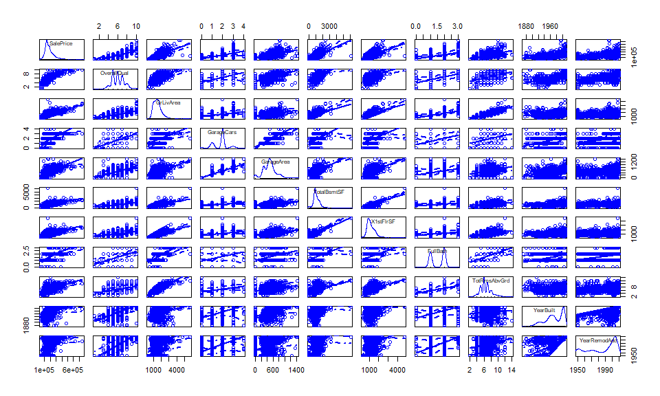

```r
select_if(house, is.numeric) %>% select(c1) -> house1
car::scatterplotMatrix(house1)
```

# سوال ۳

```r
lin = lm(formula = SalePrice ~ OverallQual + GrLivArea + GarageCars
              + GarageArea + TotalBsmtSF + `1stFlrSF`
              + FullBath + TotRmsAbvGrd + YearBuilt + YearRemodAdd, data = house1)

summary(lin)
```

```
Call:
lm(formula = SalePrice ~ OverallQual + GrLivArea + GarageCars +
    GarageArea + TotalBsmtSF + `1stFlrSF` + FullBath + TotRmsAbvGrd +
    YearBuilt + YearRemodAdd, data = house1)

Residuals:
    Min      1Q  Median      3Q     Max
-489958  -19316   -1948   16020  290558

Coefficients:
               Estimate Std. Error t value Pr(>|t|)
(Intercept)  -1.186e+06  1.291e+05  -9.187  < 2e-16 ***
OverallQual   1.960e+04  1.190e+03  16.472  < 2e-16 ***
GrLivArea     5.130e+01  4.233e+00  12.119  < 2e-16 ***
GarageCars    1.042e+04  3.044e+03   3.422 0.000639 ***
GarageArea    1.495e+01  1.031e+01   1.450 0.147384
TotalBsmtSF   1.986e+01  4.295e+00   4.625 4.09e-06 ***
`1stFlrSF`    1.417e+01  4.930e+00   2.875 0.004097 **
FullBath     -6.791e+03  2.682e+03  -2.532 0.011457 *
TotRmsAbvGrd  3.310e+01  1.119e+03   0.030 0.976404
YearBuilt     2.682e+02  5.035e+01   5.328 1.15e-07 ***
YearRemodAdd  2.965e+02  6.363e+01   4.659 3.47e-06 ***
---
Signif. codes:  0 '***' 0.001 '**' 0.01 '*' 0.05 '.' 0.1 ' ' 1

Residual standard error: 37920 on 1449 degrees of freedom
Multiple R-squared:  0.7737,    Adjusted R-squared:  0.7721
F-statistic: 495.4 on 10 and 1449 DF,  p-value: < 2.2e-16
```

# سوال ۴

نمودار قیمت واقعی بر قیمت تخمینی را میکشیم مدل خطی بینشان باید به خط y = x نزدیک باشد

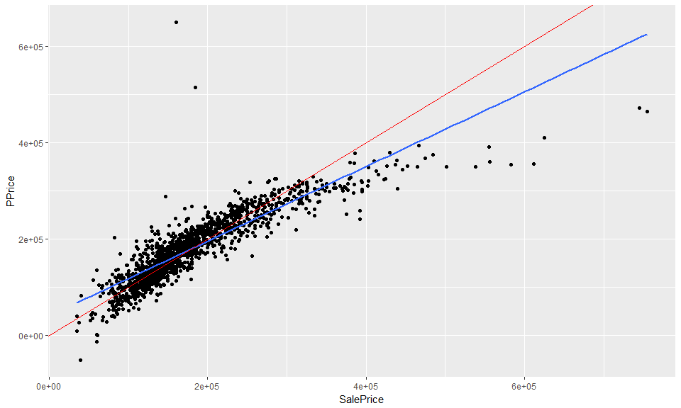

```r
house1 %>% mutate( PPrice = fitted(lin)) %>%
  ggplot(aes(x = SalePrice, y = PPrice)) + geom_point() + geom_smooth(method = "lm", se = F) + geom_abline(slope = 1, intercept = 0, color = "red")
```

# سوال ۵

```r
summary(lin)$`r.squared`
```

```
[1] 0.7736928
```

```r
summary(lin)$fstatistic
```

```
    value     numdf     dendf
 495.3802   10.0000 1449.0000
```

همچنین f statistic واریانس داده تقسیم بر واریانس خطا رو نشان میدهد پس هرچه مقدار آن بیشتر باشد بهتر است و در خلاصه مدل مقدار آن خوب است

# سوال ۶

در خلاصه مدل متغیر هایی که پی ولیو بیشتر از 0.05 دارند را حذف میکنیم زیرا فرض صفر یعنی مربوط نبودن آنها به قیمت ها رد نشده و میبینیم که مقدار f statistic بیشتر شد بنابراین مدل بهتر شده است

```r
fixed_lm = lm(formula = SalePrice ~ OverallQual + GrLivArea + GarageCars +
                TotalBsmtSF + `1stFlrSF` +
                FullBath + YearBuilt + YearRemodAdd, data = house1)


summary(fixed_lm)
```

```
Call:
lm(formula = SalePrice ~ OverallQual + GrLivArea + GarageCars +
    TotalBsmtSF + `1stFlrSF` + FullBath + YearBuilt + YearRemodAdd,
    data = house1)

Residuals:
    Min      1Q  Median      3Q     Max
-482525  -19191   -1801   16208  289639

Coefficients:
               Estimate Std. Error t value Pr(>|t|)
(Intercept)  -1.188e+06  1.284e+05  -9.255  < 2e-16 ***
OverallQual   1.959e+04  1.188e+03  16.486  < 2e-16 ***
GrLivArea     5.177e+01  3.097e+00  16.714  < 2e-16 ***
GarageCars    1.395e+04  1.817e+03   7.680 2.92e-14 ***
TotalBsmtSF   2.039e+01  4.269e+00   4.775 1.98e-06 ***
`1stFlrSF`    1.465e+01  4.919e+00   2.979  0.00294 **
FullBath     -7.184e+03  2.644e+03  -2.717  0.00666 **
YearBuilt     2.699e+02  5.017e+01   5.380 8.69e-08 ***
YearRemodAdd  2.957e+02  6.362e+01   4.649 3.64e-06 ***
---
Signif. codes:  0 '***' 0.001 '**' 0.01 '*' 0.05 '.' 0.1 ' ' 1

Residual standard error: 37920 on 1451 degrees of freedom
Multiple R-squared:  0.7734,    Adjusted R-squared:  0.7721
F-statistic: 618.9 on 8 and 1451 DF,  p-value: < 2.2e-16
```

# سوال ۷

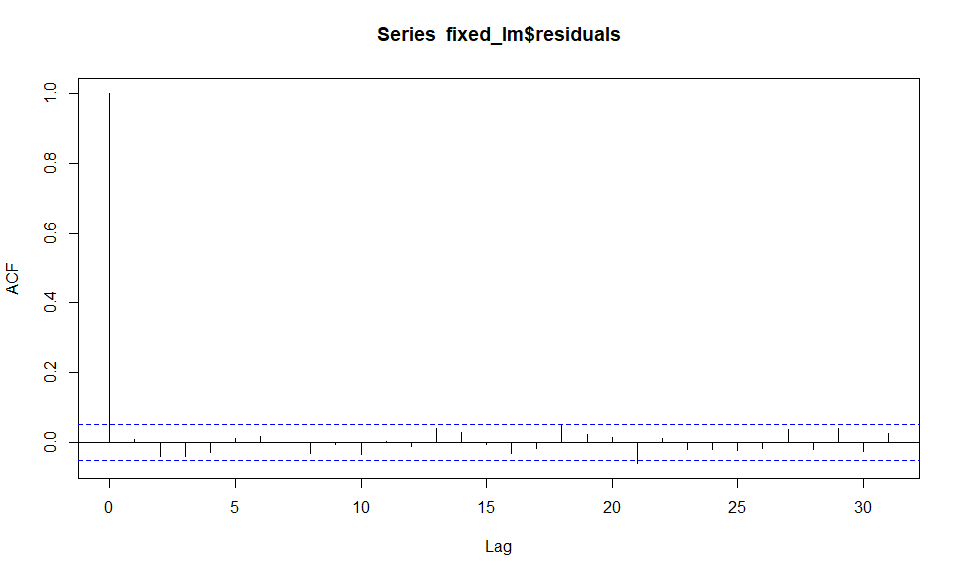

```r
acf(fixed_lm$residuals)
```

بعد از خط اول نمودار به نزدیک صفر سقوط میکند بنابراین شرط independence برقرار است.

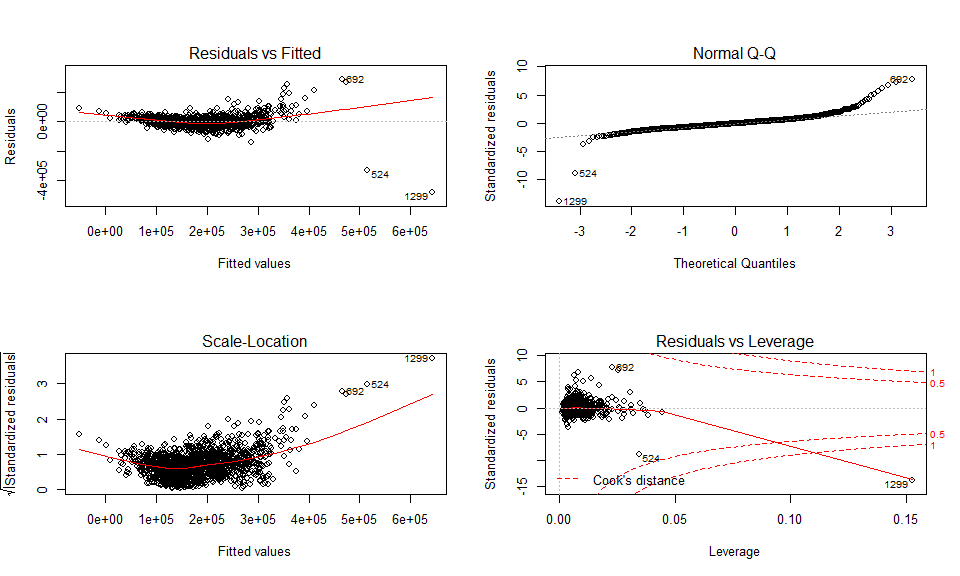

```r
par(mfrow=c(2,2))
plot(fixed_lm)
```

برای برقرار بودن شرط Constant Variance باید دونمودار سمت چپ نزدیک به خط محور x باشند اما نمودار پایین چپ این خاصیت را ندارد

برای برقرار بودن شرط نرمال بودن باید در نمودار بالا راست نقاط روی خط قرار بگیرند که این اتفاق نیز نمی افتد

# سوال ۸

همین طور که میبینیم میزان خطا از تخمین بسیار بالاست

```r
index = sample(x= 1:nrow(house1),size = 0.8*nrow(house1),replace = F)
train = house1[index,]
test =  house1[-index,]

model_lm = lm(SalePrice ~ OverallQual + GrLivArea + GarageCars +
                TotalBsmtSF + `1stFlrSF` +
                FullBath + YearBuilt + YearRemodAdd, data = train)
# prediction
train$prediction = predict( model_lm, newdata = train, type = "response" )
test$prediction  = predict( model_lm, newdata = test , type = "response" )

mean( (test$SalePrice - test$prediction) ** 2)
```

```
[1] 1261623030
```

# سوال ۹

از نگاه کردن به نمودار های سوال ۲ میابیم که ارتباط میان قیمت و overalQual خطی نیست بلکه توان دو است بنابراین در دیتا به توان دو میرسانیم تا خطی شود

```r
house1$OverallQual = house1$OverallQual ** 2
finalfit = lm(formula = SalePrice ~ OverallQual + GrLivArea + GarageCars +
                TotalBsmtSF + `1stFlrSF` +
                FullBath + YearBuilt + YearRemodAdd, data = house1)

summary(finalfit)
```

```
Call:
lm(formula = SalePrice ~ OverallQual + GrLivArea + GarageCars +
    TotalBsmtSF + `1stFlrSF` + FullBath + YearBuilt + YearRemodAdd,
    data = house1)

Residuals:
    Min      1Q  Median      3Q     Max
-483399  -18421   -1262   15836  271611

Coefficients:
               Estimate Std. Error t value Pr(>|t|)
(Intercept)  -1.022e+06  1.244e+05  -8.211 4.81e-16 ***
OverallQual   1.813e+03  9.080e+01  19.966  < 2e-16 ***
GrLivArea     4.842e+01  2.994e+00  16.172  < 2e-16 ***
GarageCars    1.292e+04  1.753e+03   7.370 2.85e-13 ***
TotalBsmtSF   1.759e+01  4.122e+00   4.267 2.11e-05 ***
`1stFlrSF`    1.364e+01  4.735e+00   2.880  0.00403 **
FullBath     -6.700e+03  2.551e+03  -2.627  0.00872 **
YearBuilt     2.480e+02  4.828e+01   5.137 3.17e-07 ***
YearRemodAdd  2.633e+02  6.128e+01   4.296 1.85e-05 ***
---
Signif. codes:  0 '***' 0.001 '**' 0.01 '*' 0.05 '.' 0.1 ' ' 1

Residual standard error: 36600 on 1451 degrees of freedom
Multiple R-squared:  0.7889,    Adjusted R-squared:  0.7877
F-statistic: 677.8 on 8 and 1451 DF,  p-value: < 2.2e-16
```

# سوال ۱۰

4649 new Artin Tajdini Artin Tajdini 0.46281 1 now Your Best Entry Your submission scored 0.46281, which is not an improvement of your best score. Keep trying!

```r
test = read_csv("house/test.csv")
test[is.na(test)] = 0


test %>%
  mutate(SalePrice = predict(finalfit, test), type = "response") %>%
  select(Id, SalePrice) %>%
  write_csv("house/lm.csv")
```